# SADM_Lab4

El Ansary Otmane, Benchekroun Omar, Bensrhier Nabil

08/05/2020

```r
word_count_train <- read.csv("datasets/word_count_train.csv")
word_count_test <- read.csv("datasets/word_count_test.csv")
tfidf_train <- read.csv("datasets/tfidf_train.csv")
tfidf_test <- read.csv("datasets/tfidf_test.csv")
```

# Question 1:

The data is a matrix for each document, the matrix is actually sparse but stored as if it was a dense matrix, which means that for most cases, we have a matrix filled with 0. This leads to unecessary memory usage.

One other way to store this kind of large scale data is to only store the values that are non equal to 0, but we also have to store their position in the document. It is basically the idea behind The Compressed Sparse Row (CSR) Format, that has an extra variable that calculates the cumulative number of non zero entries, which makes it easier to access te data.

# Question 2:

### What is the vocabulary size?

```r
# Number of variables minus the dependent variable
size <- dim(word_count_train)[2] - 1
```

```
## The vocabulary size is equal to the number of words :  19163
```

### For the review No.7 :

### The most frequent word is :

```r
col <- dim(word_count_train)[2]
No.7 <- t(word_count_train[7,-1])
names(word_count_train[,-1])[(which(No.7 == max(No.7)))]
```

```
## [1] "the"
```

### Its frequency :

```r
freq <- max(No.7)/sum(No.7)
```

```
## The frequency of the most frequent word is equal to : 0.05737705
```

### the practical consequences :

**Result:** The review No.7 of the training set contains the word *the* as the most important one since it occurs $7$ times. The practical consequence is the fact that *the* is a *Stop word*, which does not give an intuition about the positivity or the negativity of the review.

### The appearance of aaaand :

```r
aaaand <- word_count_train["aaaand"]
sum(aaaand)
```

```
## [1] 1
```

**Comment:** aaaand occurs just one time, it provides no information that can be used for this classification. May be it can be seen as a **Stop Word**, that is why we should remove it from the text before training our model.

# Question 3:

### Laplace smoothing

When applying Multinomial Naive Bayes to this classification problem, the frequency based probability might introduce zeros when multiplying probabilities, this will lead to a failure in preserving the information contributed by non-zero probabilities. therefore, Laplace smoothing approach is adopted to counter this problem.

### Training the multinomial naive Bayes on the training set in the word count representation. Set the Laplacian parameter to 1.

```r
x_train <- as.matrix(word_count_train[, -1])
y_train <- factor(word_count_train[, 1])
x_test <- as.matrix(word_count_test[, -1])
y_test <- factor(word_count_test[, 1])
### Train the Multinomial Naive Bayes
mnb <- multinomial_naive_bayes(x = x_train, y = y_train, laplace = 1)
```

```
##
## ============================ Multinomial Naive Bayes ============================
##
## - Call: multinomial_naive_bayes(x = x_train, y = y_train, laplace = 1)
## - Laplace: 1
## - Classes: 2
## - Samples: 1000
## - Features: 19163
## - Prior probabilities:
##     - 0: 0.509
##     - 1: 0.491
##
## ---------------------------------------------------------------------------------
```

### Predict labels both for training and test observations.

```r
# Classification :
y_train_hat <- predict(mnb, newdata = x_train, type = "class")
y_test_hat <- predict(mnb, newdata = x_test, type = "class")
# Confusion matrices
cm1 <- caret::confusionMatrix(y_train_hat, y_train)
cm2 <- caret::confusionMatrix(y_test_hat, y_test)
```

### Visualization of both training and test confusion matrices:

```
## Training set
```

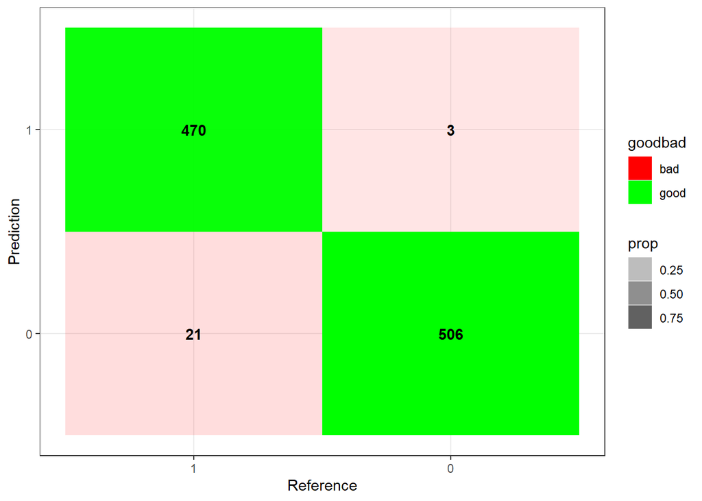

```
## Test set
```

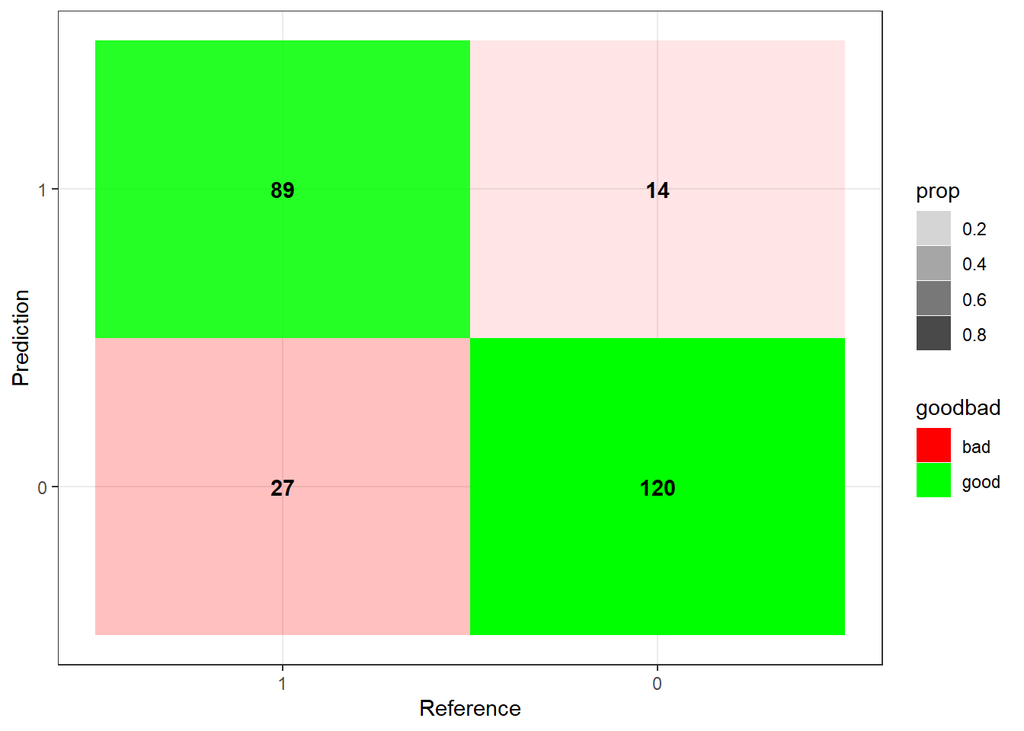

### The misclassification rate:

```r
# misclassification error on the training set
miss1 <- 1-sum(diag(cm1$table))/sum(cm1$table)
# misclassification error on the test set
miss2 <- 1-sum(diag(cm2$table))/sum(cm2$table)
```

```
## misclassification error on the training set is :   0.024
```

```
## misclassification error on the test set is     :   0.164
```

**Comment:** In general, This classifier is effective, the fact that the misclassification error for the training set is significanly lower than for the test test means that we may have an overfitting problem. A more accurate missclassification error would be to calculate it using cross validation.

# Quesion 4:

### How many positive and negative reviews are there in the training set? In the test set?

```r
# training set
positive_train <- sum(tfidf_train$y)
negative_train <- length(tfidf_train$y) - positive_train
# test set
positive_test <- sum(tfidf_test$y)
negative_test <- length(tfidf_test$y) - positive_test
```

### Visualization of results

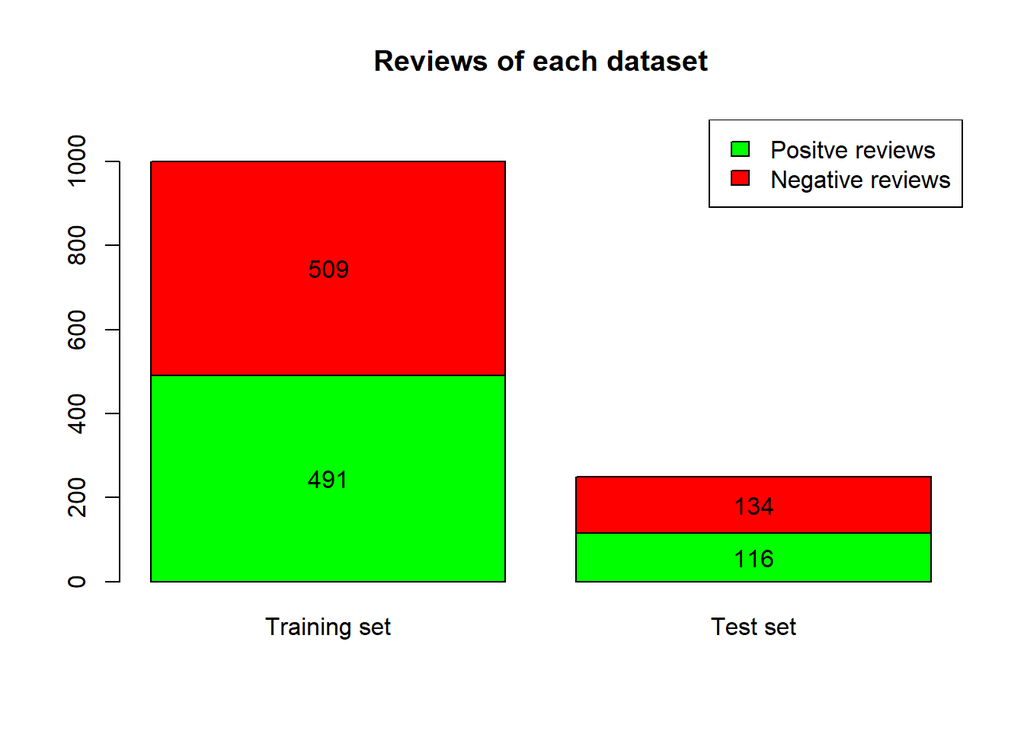

### Look at the tf-idf representation of the training set. What are the three most important words for negative reviews?

```r
# negative reviews
tf_train_neg <- tfidf_train[which(tfidf_train$y==0),-1]
# sum of each column
neg_sum <- colSums(tf_train_neg)
# sort the data
n <- length(tf_train_neg)
sorted_neg <- order(neg_sum)[(n-2):n]
names <- names(tf_train_neg)[sorted_neg]
```

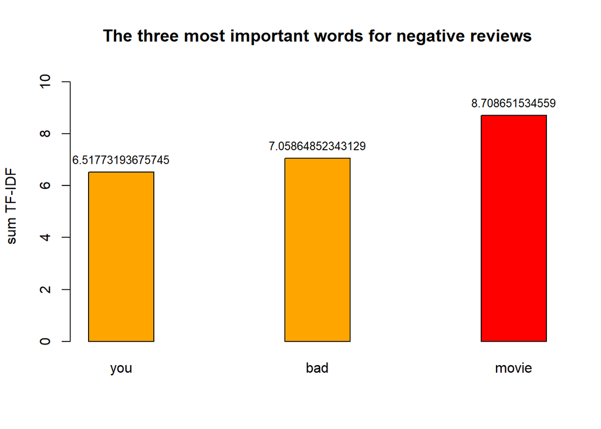

**Comment:** The most used word (“movie”) in negative reviews is not necessarily an indicator of a negative review, simply because it’s so common it appears on most movie reviews! So an accurate way of finding the real predictors is to remove the common ones in positive and negative reviews. From the three words found earlier, the only real indicator of a bad review is the word “bad”. Predictable!

# Question 5:

### Performing PCA:

Since the data is not binary encoded, variables do really have a weight. So we need to scale the data:

```r
# pca on training part of dataset
tf_train_pca <- prcomp(tfidf_train, center=TRUE, scale=TRUE)
```

Transform train and test observations usin obtained model:

```r
pred_train <- predict(tf_train_pca, newdata=tfidf_train)
pred_test <- predict(tf_train_pca, newdata=tfidf_test)
```

Keeping the first 700 principal components:

```r
pred_train <- data.frame(pred_train[, 1:700])
pred_test <- data.frame(pred_test[, 1:700])
```

### Performing LDA on the PCA-projected training set:

```r
library(MASS)
lda_model <- lda(tfidf_train$y~., data=pred_train)
```

### Predict labels both for training and test observations.

```r
y_train_pred = predict(lda_model, newdata=pred_train)$class
y_test_pred = predict(lda_model, newdata=pred_test)$class
cm1 <- caret::confusionMatrix(y_train_pred, factor(tfidf_train$y))
cm2 <- caret::confusionMatrix(y_test_pred, factor(tfidf_test$y))
```

### Visualization of both training and test confusion matrices:

```
## Training set
```

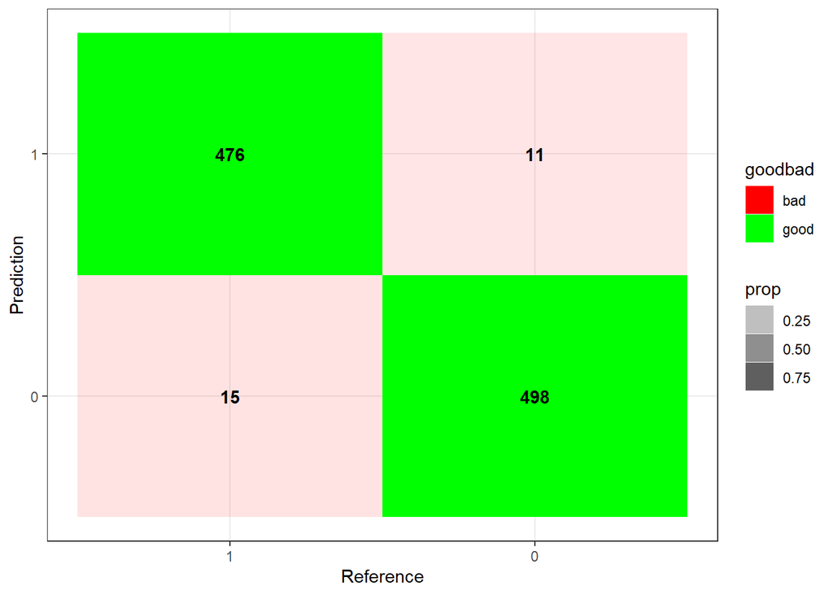

```
## Test set
```

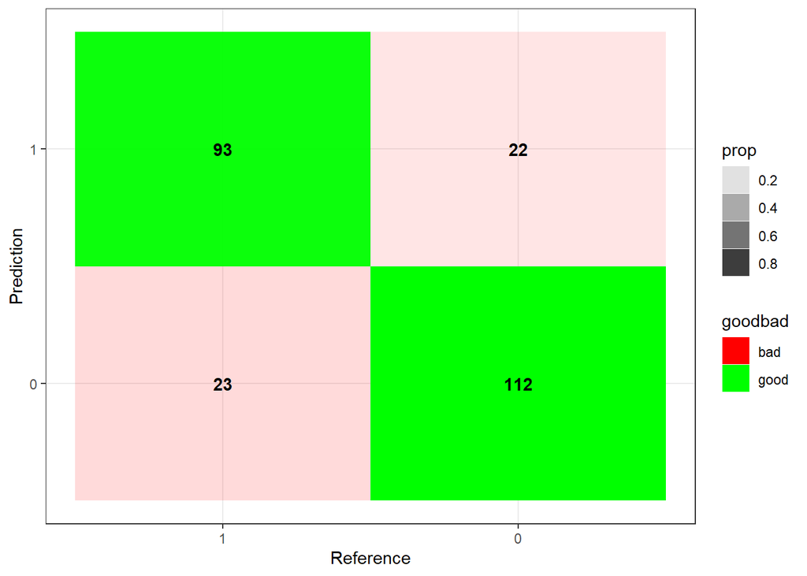

### The misclassification rate:

```r
# misclassification error on the training set
miss1 <- 1-sum(diag(cm1$table))/sum(cm1$table)
# misclassification error on the test set
miss2 <- 1-sum(diag(cm2$table))/sum(cm2$table)
```

```
## misclassification error on the training set is :   0.026
```

```
## misclassification error on the test set is     :   0.18
```

# Conclusion:

[figure not shown]

**Comment:**

- Overall, the Bayes classifier has a slightly better misclassification error than the “LDA on PCA”. This does not mean that LDA is worse, since we only used the first 700 principal components, and therefore reduced the dimension for a slight decrease in performance.
- With the lda classifier, we have similarly to the Bayes classifier an overfitting problem. Cross validation would give a more accurate result, and also would help us determine more realistically which method is better.